# Un modèle de **Rmarkdown**

## I : Bases de la mise en forme de texte Rmarkdown

### I.1 Les **md** qui sont valables dans **Rmd**

italique = *italique*

gras = **gras** = **gras**

italique gras = *italique gras*

barré = barré

### I.2 Quelques exemples sur $\LaTeX$

On écrit $X_1,\dots,X_n$ un échantillons i.i.d. de loi normale. C’est-à-dire,

$$X_1 \sim \mathcal{N}(\mu, \sigma^2)$$

avec $\mu\in \mathbb{R}$ et $\sigma \in \mathbb{R}_+^*$.

(Ref : [Latex syntax](https://en.wikibooks.org/wiki/LaTeX/Mathematics))

## II : Quelques remarques sur les plots

### II.1 : Changer la taille d’une figure

Voici les deux exemples avec **fig.height** et **fig.width** différents : Ils ne change pas la vraie taille d’une figure. Par contre, ils changent la proportion de longeur et largeur. **Attention !** Ce n’est plus valable si on utilise un Rmarkdown normal sans la configuration qu’on a fait.

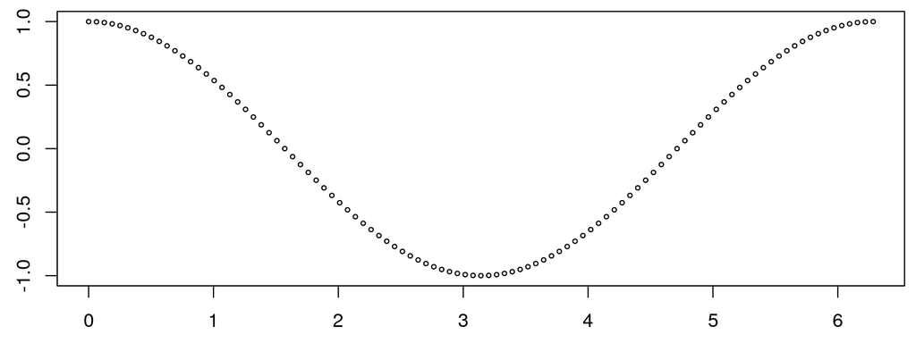

Figure 1: la courbe de Cosinus (Discription)

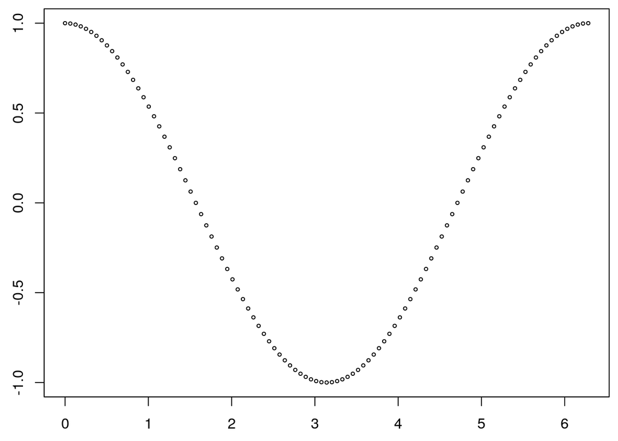

Figure 2: la même courbe de forme différente

### II.2 Matrice des figures

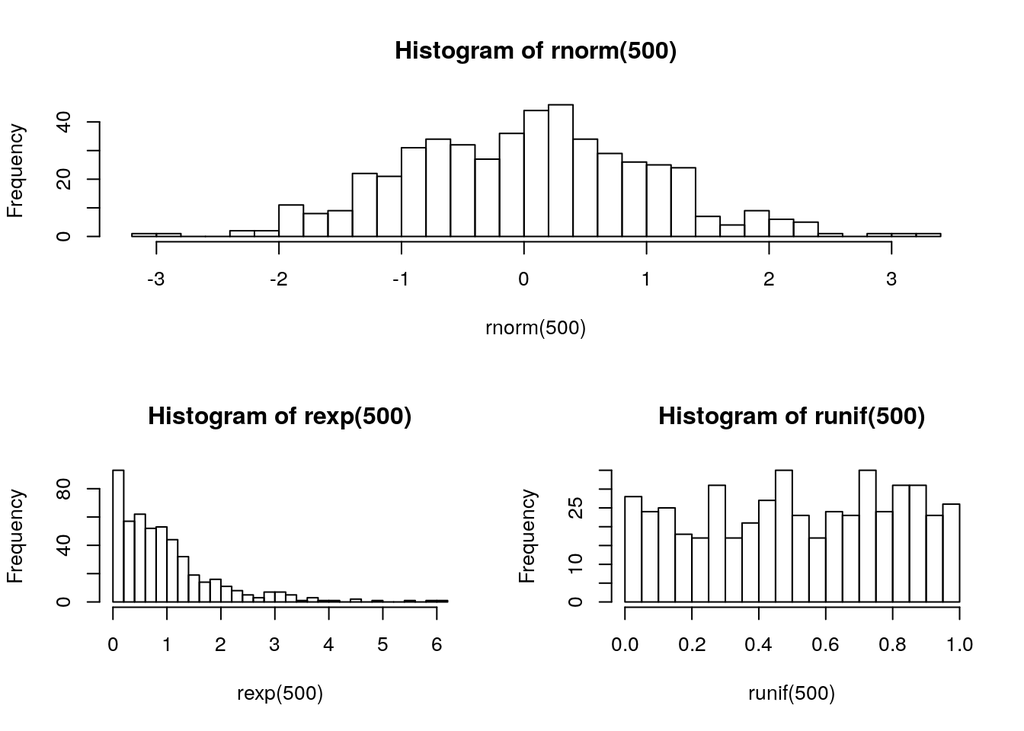

Figure 3: une matrice de histogramme

### II.3 Un exemple sur **legend()**

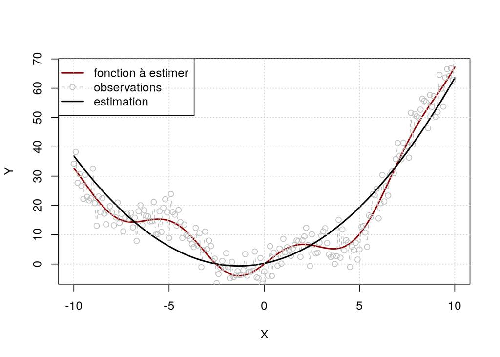

Figure 4: un exemple sur legend()

```r
X = seq(-10,10,by = 0.1)
n = length(X)
sigma = 4

epsilon = rnorm(n,0,sigma)

f = function(x){
  return(0.02*x^3 + 0.5*x^2 + 5*sin(x))
}

Y = f(X) + epsilon

######################################################################

X_expanded = cbind(X,X^2)
model = lm(Y~X_expanded)
Y_predict = predict(model,data.frame(X))

######################################################################

plot(X, f(X), type = 'l', lwd = 2, xlab = 'X', ylab = 'Y',col = 'darkred')
points(X, Y, type = 'b', lwd = 1, col = 'grey', pch = 1, lty = 2)
lines(X, Y_predict, lwd = 2)
legend('topleft', c('fonction à estimer','observations','estimation'), col = c('darkred','grey',1), lwd = c(2,1,2), pch = c(-1,1,-1), lty = c(1,2,1))
grid()
```

## III. Cross References

Pour les commentaires, on peut utiliser Figure 1 pour faire la référence.

([more details](https://github.com/ajlyons/autonumfigs))

Si on veut une figure sans caption :

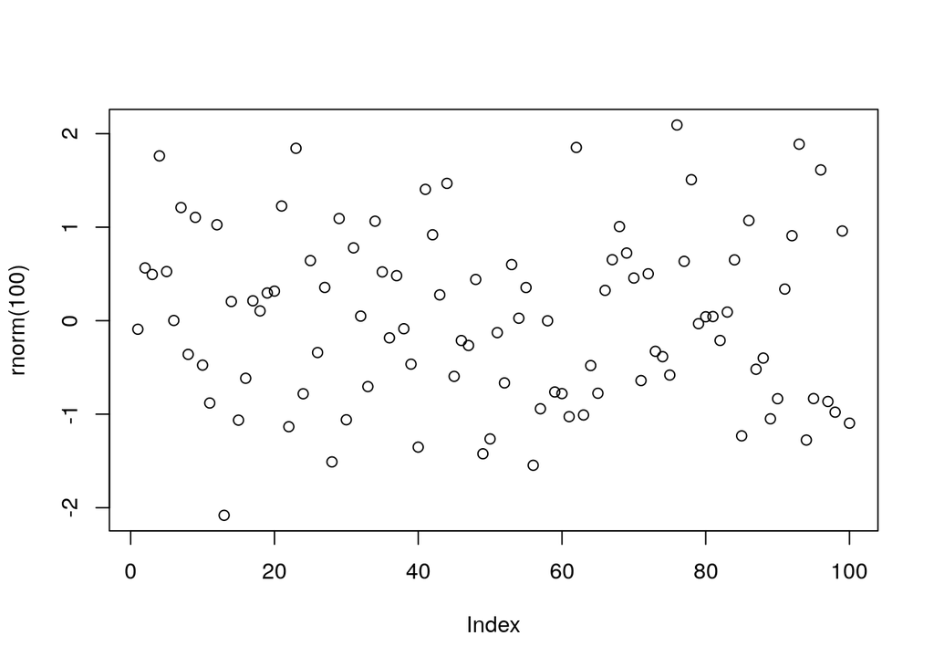

Figure 5

**Attention !** Il faut evider le cas où un code bloque crée 2 figures. On pourrais consider à faire une matrice de figures.

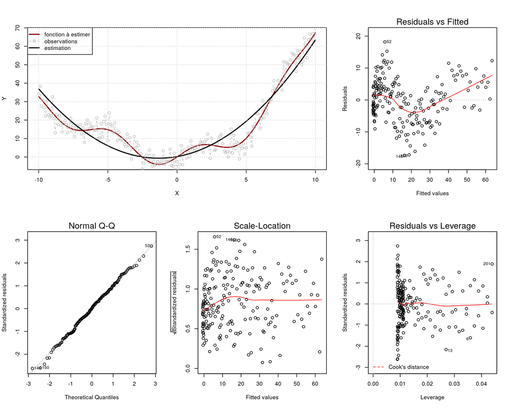

Figure 6: diagonistic de modèle linéaire

## IV. Moyen de l’usage

On peut copier coller directement ce fichier dans **Rstudio**, tous les packages nécéssaires seront installés automatiquement par **Rstudio**.

Sinon, il faut installer [**pandoc**](https://pandoc.org/) et le package **rmarkdown** de **R**.

```
# Ubuntu
sudo apt install pandoc
```

et

```
# sous R
install.packages('rmarkdown')
```

Pour compiler, il faut juste taper

```
# sous R
library(rmarkdown)
render('Rmd_template.Rmd')
```